# Assignment 6:

Marton Kovacs

# Introduction

In this lab assignment you will need to explore the factor structure of the Animal Rights Scale, a scale containing 28 items to measure attitudes towards animal experimentation and animal rights. Imagine that you are a researcher who is interested in the underlying factors that govern attitudes towards animal rights and the use of animals for different purposes. You have gathered data using the Animal Rights Scale (ARS) from 154 individuals in an online survey. Your goal is to explore the underlying factors.

# Dataset

You can load the dataset from the ‘data/’ folder.

The dataset includes the responses of 154 individuals on the following variables:

**ar1-ar28** contain the data from the 28 items of the ARS. Participants had to rate their agreement with each statement separately on a 1-5 Likert scale with the following anchors: 1 - strongly disagree, 2 – disagree, 3 - no opinion, 4 – agree, 5 - strongly agree.

The questions in the ARS were the following:

- **ar 1.** Humans have no right to displace wild animals by converting wilderness areas into farmlands, cities, and other things designed for people.
- **ar 2.** Animal research cannot be justified and should be stopped.
- **ar 3.** It is morally wrong to drink milk and eat eggs.
- **ar 4.** A human has no right to use a horse as a means of transportation (riding) or entertainment (racing).
- **ar 5.** It is wrong to wear leather jackets and pants.
- **ar 6.** Most medical research done on animals is unnecessary and invalid.
- **ar 7.** I have seriously considered becoming a vegetarian in an effort to save animal lives.
- **ar 8.** Pet owners are responsible for preventing their pets from killing other animals, such as cats killing mice or snakes eating live mice.
- **ar 9.** We need more regulations governing the use of animals in research.
- **ar 10.** It is morally wrong to eat beef and other “red” meat.
- **ar 11.** Insect pests (mosquitoes, cockroaches, flies, etc.) should be safely removed from the house rather than killed.
- **ar 12.** Animals should be granted the same rights as humans.
- **ar 13.** It is wrong to wear leather belts and shoes.
- **ar 14.** I would rather see humans die or suffer from disease than to see animals used in research.
- **ar 15.** Having extended basic rights to minorities and women, it is now time to extend them also to animals.
- **ar 16.** God put animals on Earth for man to use.
- **ar 17.** There are plenty of viable alternatives to the use of animals in biomedical and behavioral research.
- **ar 18.** Research on animals has little or no bearing on problems confronting people.
- **ar 19.** New surgical procedures and experimental drugs should be tested on animals before they are used on people.
- **ar 20.** I am very concerned about pain and suffering in animals.
- **ar 21.** Since many important questions cannot be answered by doing experiments on people, we are left with no alternatives but to do animal research.
- **ar 22.** It is a violation of an animal’s rights to be held captive as a pet by a human.
- **ar 23.** It is wrong to wear animal fur (such as mink coats).
- **ar 24.** It is appropriate for humans to kill animals that destroy human property, for example, rats, mice, and pigeons.
- **ar 25.** Most cosmetics research done on animals is unnecessary and invalid.
- **ar 26.** It is morally wrong to eat chicken and fish.
- **ar 27.** Most psychological research done on animals is unnecessary and invalid.
- **ar 28.** Hunters play an important role in regulating the size of deer populations.

You can get more information about the ARS here: http://core.ecu.edu/psyc/wuenschk/Animals/Anim-Rights-Q.htm

And also here:

Wuensch, K. L., Jenkins, K. W., & Poteat, G. M. (2002). Misanthropy, idealism, and attitudes towards animals. *Anthrozoös, 15*, 139-149

Sharp, H. W., Wuensch, K. L., Eppler, M. A., & Harju, B. L. (2006, April). Narcissism, empathy, and attitudes towards animals. In *Spring Conference of the North Carolina Psychological Association and North Carolina Psychological Foundation, Charlotte, NC.*

A few other questions were also included in the questionnaire:

**sex:** The self reported sex of the participant. This is a categorical variable coded as 1 – female, 2 – male.

**party:** Self reported party affiliation of the person (in the USA). This is a categorical variable coded as 1 - democrat, 2 - republican, 3 - other, 4 – none.

**liberal:** This variable contains data from a question: please rate how conservative or liberal are you. On a scale of 1-5 where 1 means very conservative and 5 means very liberal.

# Task

Your task is to do an exploratory factor analysis using the items in the ARS to identify the latent factors underlying the responses. First of all, start by exploring the descriptive statistics and correlations in the dataset to get more familiar with it and to identify any unusual cases or coding errors. Make sure to check the assumptions of factorability and multivariate normality and address them as necessary. You have a free hand in choosing the extraction and rotation methods. You can also exclude items if you see this necessary, but **do not exclude more than 8 items** in this assignment. (If you still find the average communality below expectations, just report this as a limitation in your report, but continue the task). Keep notes of the steps and different setting/methods you tried during the exploratory factor analysis.

*(The factor structure of this scale has been previously analyzed by others. If you want, you can use these previous research reports to guide your exploration, or you can ignore them. In any case, do not base your decisions solely on these research reports. Do your own work and base your decisions on your own findings on this dataset.)*

When you have arrived at the factor structure you consider final, give names to the factors you derived from the data. Save the factor scores and build a linear regression model to predict how conservative or liberal participants are (using the “liberal” variable as a dependent variable) with the factors you identified as the predictors.

**To simplify the task you can regard all likert scale variables (ar1-28 and liberal) as if they were continuous variables!** So you do not have to use polychoric correlation for factor analysis and you do not have to perform ordinal regression.

# What to report

Report if you have found any unusual things (outliers or coding errors) in the dataset and how you dealt with them. Report the results of the assumption checks for factorability and multivariate normality. If any of the assumptions were found to be violated, report what was done to handle that.

Report the number of factors you chose to keep in your final factor structure and give a rationale why. Include the parallel analysis scree plot in your report. Report the post-extraction eignevalues, variance explained, and cumulative variance explained by the final factors in a table format. Report the average post-extraction communality of the items.

Report which rotation you chose to use (if any) and why. Report the final factor structure including the factor names. Also, report the post-extraction commonalities of each item and the loadings of the items on the final factors in a table format. (These can be reported in the same table). This table should contain the loadings that you used to interpret the factors in your analysis (e.g. the loadings listed in the rotated factor matrix or the pattern matrix). The table should be structured in a way to help the reader easily see which items load high on which factors.

Report if you have excluded any items, and give a rationale for each.

Report which factor (if any) was the most influential predictor of how liberal a person is in the linear regression model and explain what do you base this assessment on.

# What to discuss

Talk about the limitations of your study and findings.

# Solution

## Read the data

Read the Animal Rights Scale (ARQ) dataset from the ‘data/’ folder. Pay attention to the extension.

```r
current_folder <- dirname(rstudioapi::getSourceEditorContext()$path)
data_folder <- file.path(dirname(current_folder), "data")

df_raw <- read.csv(file.path(data_folder, "assignment_5_dataset.csv"))
datatable(head(df_raw, 3))
```

|  | ar1 | ar2 | ar3 | ar4 | ar5 | ar6 | ar7 | ar8 | ar9 | ar10 | ar11 | ar12 | ar13 | ar14 | ar15 | ar16 | ar17 | ar18 | ar19 | ar20 | ar21 | ar22 | ar23 | ar24 | ar25 | ar26 | ar27 | ar28 | sex | … |
| --- | --- | --- | --- | --- | --- | --- | --- | --- | --- | --- | --- | --- | --- | --- | --- | --- | --- | --- | --- | --- | --- | --- | --- | --- | --- | --- | --- | --- | --- | --- |
| 1 | 4 | 1 | 1 | 1 | 1 | 1 | 1 | 1 | 1 | 1 | 1 | 1 | 1 | 1 | 1 | 2 | 2 | 1 | 5 | 1 | 4 | 1 | 1 | 4 | 2 | 1 | 3 | 5 | 1 | … |
| 2 | 2 | 1 | 1 | 2 | 1 | 1 | 1 | 1 | 2 | 1 | 1 | 2 | 1 | 1 | 1 | 4 | 2 | 3 | 4 | 3 | 4 | 3 | 2 | 3 | 3 | 1 | 4 | 5 | 1 | … |
| 3 | 4 | 1 | 1 | 2 | 1 | 2 | 1 | 1 | 3 | 1 | 1 | 3 | 2 | 1 | 2 | 4 | 2 | 2 | 4 | 4 | 4 | 2 | 2 | 4 | 4 | 1 | 2 | 4 | 1 | … |

## EDA

```r
skim(df_raw)
```

Data summary

| Name | df_raw |
| --- | --- |
| Number of rows | 154 |
| Number of columns | 31 |
| _______________________ |  |
| Column type frequency: |  |
| numeric | 31 |
| ________________________ |  |
| Group variables | None |

**Variable type: numeric**

| skim_variable | n_missing | complete_rate | mean | sd | p0 | p25 | p50 | p75 | p100 | hist |
| --- | --- | --- | --- | --- | --- | --- | --- | --- | --- | --- |
| ar1 | 2 | 0.99 | 3.21 | 1.12 | 1 | 2 | 3 | 4 | 5 | ▂▇▇▇▃ |
| ar2 | 1 | 0.99 | 2.58 | 1.12 | 1 | 2 | 2 | 3 | 5 | ▂▇▅▂▂ |
| ar3 | 0 | 1.00 | 1.45 | 0.71 | 1 | 1 | 1 | 2 | 4 | ▇▃▁▁▁ |
| ar4 | 0 | 1.00 | 1.74 | 0.71 | 1 | 1 | 2 | 2 | 4 | ▇▇▁▂▁ |
| ar5 | 0 | 1.00 | 1.98 | 0.90 | 1 | 1 | 2 | 2 | 5 | ▆▇▃▁▁ |
| ar6 | 0 | 1.00 | 2.38 | 0.98 | 1 | 2 | 2 | 3 | 5 | ▂▇▃▂▁ |
| ar7 | 0 | 1.00 | 2.06 | 1.10 | 1 | 1 | 2 | 2 | 5 | ▆▇▂▂▁ |
| ar8 | 0 | 1.00 | 2.05 | 1.01 | 1 | 1 | 2 | 2 | 5 | ▆▇▂▂▁ |
| ar9 | 0 | 1.00 | 3.45 | 1.08 | 1 | 3 | 4 | 4 | 5 | ▁▂▅▇▃ |
| ar10 | 1 | 0.99 | 1.85 | 0.89 | 1 | 1 | 2 | 2 | 5 | ▆▇▁▁▁ |
| ar11 | 0 | 1.00 | 1.92 | 1.05 | 1 | 1 | 2 | 2 | 5 | ▇▆▂▁▁ |
| ar12 | 0 | 1.00 | 2.57 | 1.05 | 1 | 2 | 3 | 3 | 5 | ▅▇▇▃▁ |
| ar13 | 0 | 1.00 | 1.91 | 0.88 | 1 | 1 | 2 | 2 | 5 | ▇▇▃▁▁ |
| ar14 | 1 | 0.99 | 1.53 | 0.74 | 1 | 1 | 1 | 2 | 5 | ▇▅▁▁▁ |
| ar15 | 0 | 1.00 | 2.41 | 1.01 | 1 | 2 | 2 | 3 | 5 | ▅▇▇▃▁ |
| ar16 | 0 | 1.00 | 3.10 | 1.01 | 1 | 2 | 3 | 4 | 5 | ▁▅▇▅▂ |
| ar17 | 0 | 1.00 | 2.96 | 0.94 | 1 | 2 | 3 | 4 | 5 | ▁▆▇▅▁ |
| ar18 | 1 | 0.99 | 2.04 | 0.79 | 1 | 2 | 2 | 2 | 5 | ▃▇▂▁▁ |
| ar19 | 1 | 0.99 | 3.59 | 0.96 | 1 | 3 | 4 | 4 | 5 | ▁▂▅▇▂ |
| ar20 | 0 | 1.00 | 3.50 | 0.99 | 1 | 3 | 4 | 4 | 5 | ▁▂▆▇▃ |
| ar21 | 0 | 1.00 | 3.58 | 0.97 | 1 | 3 | 4 | 4 | 5 | ▁▂▂▇▂ |
| ar22 | 1 | 0.99 | 1.96 | 0.87 | 1 | 1 | 2 | 2 | 5 | ▅▇▂▁▁ |
| ar23 | 0 | 1.00 | 2.58 | 1.19 | 1 | 2 | 2 | 3 | 5 | ▅▇▅▅▂ |
| ar24 | 0 | 1.00 | 3.05 | 1.00 | 1 | 2 | 3 | 4 | 5 | ▂▆▇▇▁ |
| ar25 | 0 | 1.00 | 3.34 | 1.04 | 1 | 3 | 3 | 4 | 5 | ▁▅▇▇▃ |
| ar26 | 0 | 1.00 | 1.76 | 0.90 | 1 | 1 | 2 | 2 | 5 | ▇▇▂▁▁ |
| ar27 | 0 | 1.00 | 2.42 | 0.93 | 1 | 2 | 2 | 3 | 5 | ▂▇▅▂▁ |
| ar28 | 0 | 1.00 | 3.71 | 1.08 | 1 | 3 | 4 | 4 | 5 | ▁▂▂▇▅ |
| sex | 1 | 0.99 | 1.19 | 0.39 | 1 | 1 | 1 | 1 | 2 | ▇▁▁▁▂ |
| party | 1 | 0.99 | 2.91 | 1.24 | 1 | 2 | 4 | 4 | 4 | ▃▃▁▁▇ |
| liberal | 1 | 0.99 | 2.91 | 0.85 | 1 | 2 | 3 | 3 | 5 | ▁▅▇▂▁ |

```r
ars_items <- paste0("ar", 1:28)

sapply(df_raw[ars_items], range, na.rm = TRUE)
```

```
##      ar1 ar2 ar3 ar4 ar5 ar6 ar7 ar8 ar9 ar10 ar11 ar12 ar13 ar14 ar15 ar16
## [1,]   1   1   1   1   1   1   1   1   1    1    1    1    1    1    1    1
## [2,]   5   5   4   4   5   5   5   5   5    5    5    5    5    5    5    5
##      ar17 ar18 ar19 ar20 ar21 ar22 ar23 ar24 ar25 ar26 ar27 ar28
## [1,]    1    1    1    1    1    1    1    1    1    1    1    1
## [2,]    5    5    5    5    5    5    5    5    5    5    5    5
```

**ANSWER** Based on the histograms and percentiles shown in the skim report I see that there are no coding errors in the data, all are between 1 and 5 for the AR variables.

## Data manipulation

```r
df_clean <- df_raw %>%
  mutate(
    # Recode the 'sex' variable
    sex = factor(sex,
                 levels = c(1, 2),
                 labels = c("male", "female")),

    # Recode the 'party' variable
    party = factor(party,
                   levels = c(1, 2, 3, 4),
                   labels = c("democrat", "republican", "other", "none"))
  )
```

# Creating a correlation matrix

**Note:** Remember to only include the variables of the questionnaire that will be part of the factor analysis.

```r
df <- df_raw %>%
  select(-sex, -party, -liberal)
```

Create the correlation matrix.

```r
cormat <- cor(
  df,
  use = "pairwise.complete.obs"
  )

# Function to check for
# - Non-finite elements
# - Zero variance vars
# - If the matrix is symmetric
check_cor_matrix <- function(M) {
  list(
    non_finite = sum(!is.finite(M)),
    zero_variance_vars = which(apply(M, 1, function(x) all(is.na(x)))),
    symmetric = isSymmetric(M)
  )
}

check_cor_matrix(cormat)
```

```
## $non_finite
## [1] 0
##
## $zero_variance_vars
## named integer(0)
##
## $symmetric
## [1] TRUE
```

Let’s see if any of the correlations are very high.

```r
thr <- 0.80

inds <- which(abs(cormat) > thr & row(cormat) != col(cormat), arr.ind = TRUE)

data.frame(
  var1 = rownames(cormat)[inds[,1]],
  var2 = colnames(cormat)[inds[,2]],
  r    = cormat[inds]
)
```

```
##   var1 var2         r
## 1 ar13  ar5 0.8337243
## 2  ar5 ar13 0.8337243
```

The highest correlation is between ar5 and ar13, it’s 0.83, which is quite high - but I wouldn’t make any decisions about removing them yet - I’d like to see how they perform in the factor analysis.

## Visualizing the correlation matrix

Create a visualization of the results of the correlation matrix.

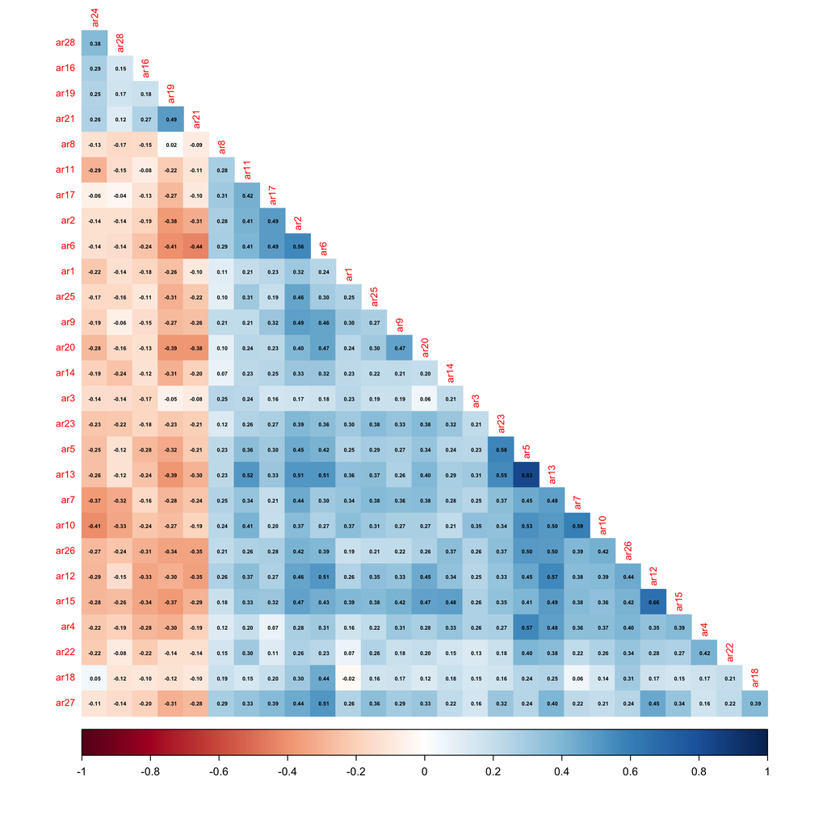

```r
corrplot(cormat,
         method = "color",
         type = "lower",       # Show only the lower half
         order = "hclust",     # reorders items based on their correlation,
                               # grouping similar items together.
         addCoef.col = "black",
         number.cex = 0.4,     # make the numbers small so they fit
         tl.cex = 0.7,
         addrect = 3,
         diag = FALSE)
```

**ANSWER** Checking on the matrix, there is no significant problem with multicollinearity - I see a mass of correlations below 0.3 which might be an indication that the factor structure won’t be very robust, but since we cannot have effect on the experiment itself, I’ll revisit this when I see the factor structre.

## Test for factorability

Calculate the KMO score.

```r
KMO(cormat)
```

```
## Kaiser-Meyer-Olkin factor adequacy
## Call: KMO(r = cormat)
## Overall MSA =  0.88
## MSA for each item =
##  ar1  ar2  ar3  ar4  ar5  ar6  ar7  ar8  ar9 ar10 ar11 ar12 ar13 ar14 ar15 ar16
## 0.86 0.94 0.84 0.87 0.82 0.91 0.92 0.84 0.87 0.89 0.86 0.90 0.86 0.87 0.90 0.87
## ar17 ar18 ar19 ar20 ar21 ar22 ar23 ar24 ar25 ar26 ar27 ar28
## 0.83 0.74 0.88 0.92 0.83 0.90 0.87 0.85 0.90 0.94 0.88 0.77
```

**ANSWER** The overall KMO of 0.88 indicates excellent sampling adequacy, meaning the data are highly suitable for factor analysis. All items exceed acceptable levels, with only a few (e.g., ar18 = 0.74, ar28 = 0.77) approaching the lower bound but still within an acceptable range.

## Test for multivariate normality

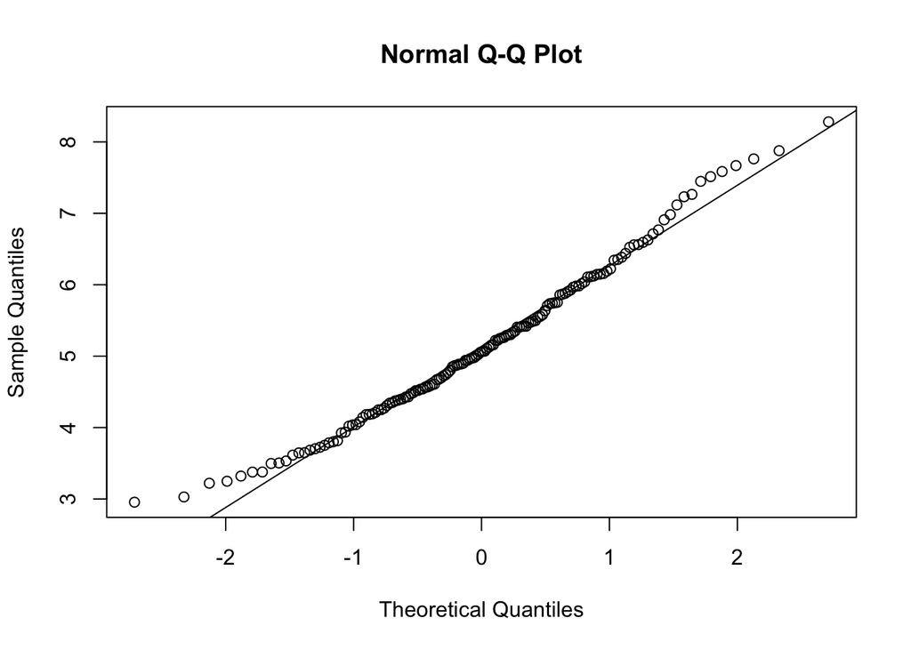

```r
normality_results <- mardia(df, plot = TRUE)
```

```r
normality_results
```

```
## Call: mardia(x = df, plot = TRUE)
##
## Mardia tests of multivariate skew and kurtosis
## Use describe(x) the to get univariate tests
## n.obs = 150   num.vars =  28
## b1p =  235.5   skew =  5887.38  with probability  <=  1.3e-71
##  small sample skew =  6013.37  with probability <=  2.5e-80
## b2p =  920.52   kurtosis =  12.03  with probability <=  0
```

**ANSWER** The Mardia test shows strong, highly significant deviations from multivariate normality: both Mardia’s skewness and kurtosis have essentially zero p-values, so the multivariate normality assumption is clearly violated. Also, the Q-Q plot shows problems at the head and the tail - visibly moving away from the line.

Test for skewness and kurtosis.

**ANSWER** Since we know that the multivariate normality is violated, we specifically focus on problematic variables.

```r
desc <- psych::describe(df)
problem_vars <- subset(desc,
                       abs(skew) > 1 | abs(kurtosis) > 1,
                       select = c(mean, sd, skew, kurtosis))
problem_vars
```

```
##      mean   sd skew kurtosis
## ar3  1.45 0.71 1.77     3.31
## ar7  2.06 1.10 1.13     0.67
## ar10 1.85 0.89 1.36     2.22
## ar11 1.92 1.05 1.07     0.42
## ar14 1.53 0.74 1.58     3.18
## ar18 2.04 0.79 0.98     1.49
## ar22 1.96 0.87 0.98     1.16
## ar26 1.76 0.90 1.39     2.09
```

There are 8 variables where either or both the skew and kurtosis are above 1.

```r
problem_vars_higher_threshold <- subset(desc,
                       abs(skew) > 1.5 | abs(kurtosis) > 1.5,
                       select = c(mean, sd, skew, kurtosis))
problem_vars_higher_threshold
```

```
##      mean   sd skew kurtosis
## ar3  1.45 0.71 1.77     3.31
## ar10 1.85 0.89 1.36     2.22
## ar14 1.53 0.74 1.58     3.18
## ar26 1.76 0.90 1.39     2.09
```

This resulted in 4 variables with higher kurtosis and skewness. I don’t drop them yet - let’s see the factor structure first.

Since normality is violated, I don’t use Maximum Likelihood - I will pick MinRes.

## Create scree plot

Create a scree plot to help the decision on how many factors to include.

Since the Mardia test for multivariate normality has failed (is significant), I pick MINRes as a more robust method for factor analysis.

```r
pa_results <- fa.parallel(
  df,
  fm = "minres",
  fa = "fa" # without this it shows PC too which is confusing
  )
```

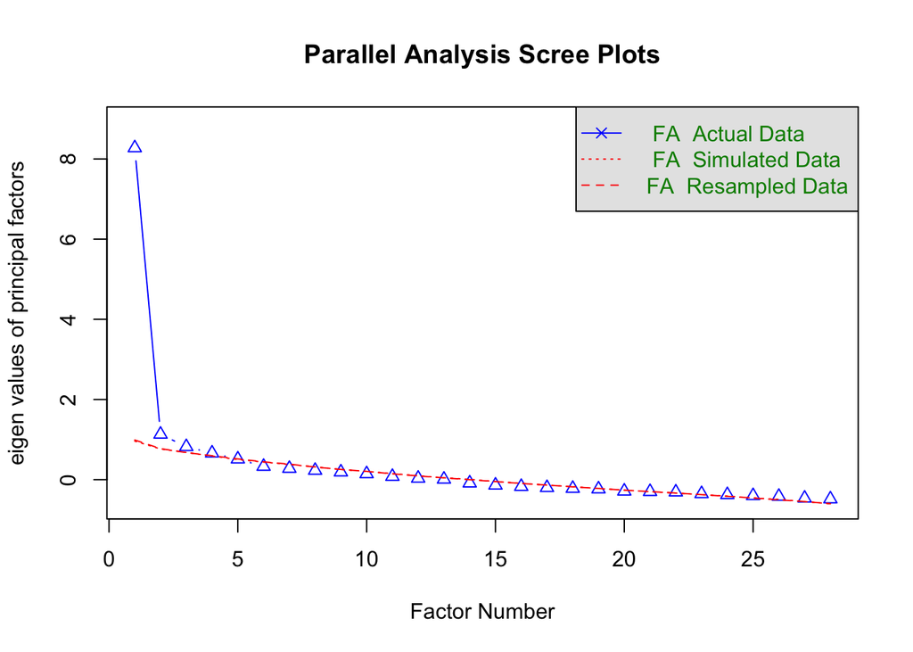

```
## Parallel analysis suggests that the number of factors =  4  and the number of components =  NA
```

```r
print(pa_results)
```

```
## Call: fa.parallel(x = df, fm = "minres", fa = "fa")
## Parallel analysis suggests that the number of factors =  4  and the number of components =  NA
##
##  Eigen Values of
##
##  eigen values of factors
##  [1]  8.28  1.13  0.82  0.66  0.51  0.33  0.28  0.23  0.19  0.15  0.08  0.03
## [13]  0.01 -0.09 -0.14 -0.17 -0.20 -0.22 -0.23 -0.29 -0.30 -0.31 -0.35 -0.38
## [25] -0.40 -0.42 -0.46 -0.48
##
##  eigen values of simulated factors
##  [1]  0.96  0.77  0.68  0.59  0.50  0.44  0.38  0.32  0.25  0.21  0.15  0.10
## [13]  0.05  0.01 -0.05 -0.09 -0.14 -0.17 -0.22 -0.26 -0.30 -0.33 -0.37 -0.41
## [25] -0.46 -0.49 -0.55 -0.60
##
##  eigen values of components
##  [1] 8.92 1.84 1.56 1.40 1.25 1.06 1.04 0.94 0.90 0.88 0.82 0.76 0.70 0.67 0.61
## [16] 0.58 0.51 0.46 0.45 0.41 0.37 0.35 0.35 0.33 0.30 0.22 0.21 0.10
##
##  eigen values of simulated components
## [1] NA
```

**ANSWER** First I used psych library’s scree plot, but I removed it - it wasn’t informative enough. Both the plot and the textual answer suggests we should go with 4 factors, because for the first 4 factor the actual data’s eigenvalues are above the simulated data’s factor values. Factor 5 has only 0.01 higher eigenvalue than simulated, which is not convincing for me - so I decided to go with 4 factors.

## Run the factor analysis

Run the factor analysis with the chosen number of factors.

**ANSWER** I picked minres because of the violation of multivariate normality. I picked oblimin rotation because in psychology we accept the fact that factors correlate.

```r
fa_model <- fa(df,
               nfactors = 4,       # From our parallel analysis
               fm = "minres",      # Because data wasn't normal
               rotate = "oblimin") # Use an oblique (correlated) rotation
# 'cut = 0.3' hides small loadings < 0.3
print(fa_model, sort = TRUE, cut = 0.3)
```

```
## Factor Analysis using method =  minres
## Call: fa(r = df, nfactors = 4, rotate = "oblimin", fm = "minres")
## Standardized loadings (pattern matrix) based upon correlation matrix
##      item   MR1   MR2   MR4   MR3   h2   u2 com
## ar5     5  0.93                   0.82 0.18 1.0
## ar13   13  0.72                   0.75 0.25 1.2
## ar4     4  0.62                   0.45 0.55 1.4
## ar22   22  0.49                   0.25 0.75 1.0
## ar26   26  0.47                   0.43 0.57 1.4
## ar23   23  0.30                   0.34 0.66 2.6
## ar16   16                         0.17 0.83 2.6
## ar17   17        0.70             0.44 0.56 1.0
## ar6     6        0.63             0.68 0.32 1.7
## ar27   27        0.60             0.44 0.56 1.1
## ar2     2        0.60             0.58 0.42 1.2
## ar11   11        0.43             0.39 0.61 2.3
## ar8     8        0.40             0.22 0.78 2.0
## ar9     9        0.38             0.34 0.66 2.3
## ar18   18        0.37             0.24 0.76 2.7
## ar25   25                         0.27 0.73 2.5
## ar10   10              0.62       0.60 0.40 1.4
## ar7     7              0.60       0.52 0.48 1.1
## ar24   24             -0.58       0.39 0.61 1.4
## ar28   28             -0.47       0.21 0.79 1.1
## ar1     1              0.42       0.26 0.74 1.6
## ar3     3                         0.19 0.81 2.8
## ar21   21                   -0.61 0.42 0.58 1.0
## ar19   19                   -0.53 0.42 0.58 1.2
## ar20   20                    0.45 0.42 0.58 1.7
## ar15   15              0.31  0.33 0.52 0.48 3.0
## ar12   12                         0.49 0.51 3.7
## ar14   14                         0.23 0.77 3.3
##
##                        MR1  MR2  MR4  MR3
## SS loadings           3.39 3.36 2.71 2.04
## Proportion Var        0.12 0.12 0.10 0.07
## Cumulative Var        0.12 0.24 0.34 0.41
## Proportion Explained  0.29 0.29 0.24 0.18
## Cumulative Proportion 0.29 0.59 0.82 1.00
##
```

[output cut: 13 more lines]

```
## The root mean square of the residuals (RMSR) is  0.05
## The df corrected root mean square of the residuals is  0.06
##
## The harmonic n.obs is  153 with the empirical chi square  257.39  with prob <  0.73
## The total n.obs was  154  with Likelihood Chi Square =  376.96  with prob <  2.5e-05
##
## Tucker Lewis Index of factoring reliability =  0.895
## RMSEA index =  0.05  and the 90 % confidence intervals are  0.037 0.062
## BIC =  -993.1
## Fit based upon off diagonal values = 0.98
## Measures of factor score adequacy
##                                                    MR1  MR2  MR4  MR3
## Correlation of (regression) scores with factors   0.95 0.92 0.90 0.86
## Multiple R square of scores with factors          0.91 0.85 0.81 0.74
## Minimum correlation of possible factor scores     0.82 0.70 0.62 0.49
```

Sort the communality scores in decreasing order.

```r
# Access the communalities (h2) from your model
communalities <- fa_model$communalities

# Sort them in decreasing order
sorted_communalities <- sort(communalities, decreasing = TRUE)
sorted_communalities
```

```
##       ar5      ar13       ar6      ar10       ar2      ar15       ar7      ar12
## 0.8200042 0.7492595 0.6820336 0.6010871 0.5820400 0.5208451 0.5204654 0.4889567
##       ar4      ar17      ar27      ar26      ar20      ar21      ar19      ar11
## 0.4518480 0.4417919 0.4362327 0.4258205 0.4220692 0.4215231 0.4153695 0.3920422
##      ar24      ar23       ar9      ar25       ar1      ar22      ar18      ar14
## 0.3897379 0.3443318 0.3370724 0.2717226 0.2594505 0.2476490 0.2436367 0.2289638
##       ar8      ar28       ar3      ar16
## 0.2224179 0.2104902 0.1934868 0.1685446
```

Calculate the mean communality scores.

```r
mean(communalities)
```

```
## [1] 0.4103176
```

**ANSWER** The mean of communalities is 0.41, which is quite low, so I need to refine my variables.

```r
df_refined <- df %>%
  select(-ar3, -ar14, -ar10, -ar26)

fa_model <- fa(df_refined,
               nfactors = 4,       # From our parallel analysis
               fm = "minres",      # Because data wasn't normal
               rotate = "oblimin") # Use an oblique (correlated) rotation

# 'cut = 0.3' hides small loadings < 0.3
communalities <- fa_model$communalities

# Sort them in decreasing order
sorted_communalities <- sort(communalities, decreasing = TRUE)
sorted_communalities
```

```
##       ar5      ar13       ar6       ar2      ar15       ar7      ar12      ar21
## 0.8858076 0.7787304 0.7096017 0.5848609 0.5101169 0.4901591 0.4852956 0.4806270
##      ar17      ar27       ar4      ar20      ar19      ar11      ar24      ar23
## 0.4542064 0.4419239 0.4369359 0.4242436 0.3887144 0.3881375 0.3863875 0.3566134
##       ar9      ar25      ar18       ar1      ar22       ar8      ar28      ar16
## 0.3397221 0.2792177 0.2691628 0.2543171 0.2384359 0.1880618 0.1752480 0.1692991
```

```r
print(mean(communalities))
```

```
## [1] 0.4214928
```

**ANSWER** Nope, it didn’t help at all. Now, I try removing the columns with the lowest communalities in the original model.

```r
print(fa_model, sort = TRUE, cut = 0.3)
```

```
## Factor Analysis using method =  minres
## Call: fa(r = df_refined, nfactors = 4, rotate = "oblimin", fm = "minres")
## Standardized loadings (pattern matrix) based upon correlation matrix
##      item   MR2   MR1   MR3   MR4   h2   u2 com
## ar17   14  0.72                   0.45 0.55 1.1
## ar6     5  0.61              0.35 0.71 0.29 1.8
## ar2     2  0.60                   0.58 0.42 1.2
## ar27   23  0.58                   0.44 0.56 1.2
## ar11    9  0.44                   0.39 0.61 2.4
## ar8     7  0.40                   0.19 0.81 1.5
## ar18   15  0.38       -0.32       0.27 0.73 2.7
## ar9     8  0.36                   0.34 0.66 2.3
## ar25   22                         0.28 0.72 2.5
## ar5     4        0.99             0.89 0.11 1.0
## ar13   11        0.75             0.78 0.22 1.1
## ar4     3        0.61             0.44 0.56 1.4
## ar22   19        0.47             0.24 0.76 1.0
## ar23   20        0.34             0.36 0.64 2.3
## ar24   21             -0.57       0.39 0.61 1.3
## ar7     6              0.54       0.49 0.51 1.3
## ar28   24             -0.41       0.18 0.82 1.0
## ar1     1              0.40       0.25 0.75 1.5
## ar15   12              0.36       0.51 0.49 2.9
## ar21   18                   -0.68 0.48 0.52 1.0
## ar19   16                   -0.49 0.39 0.61 1.3
## ar20   17                    0.40 0.42 0.58 2.2
## ar12   10                         0.49 0.51 3.8
## ar16   13                         0.17 0.83 2.6
##
##                        MR2  MR1  MR3  MR4
## SS loadings           3.20 3.05 2.02 1.85
## Proportion Var        0.13 0.13 0.08 0.08
## Cumulative Var        0.13 0.26 0.34 0.42
## Proportion Explained  0.32 0.30 0.20 0.18
## Cumulative Proportion 0.32 0.62 0.82 1.00
##
##  With factor correlations of
##      MR2  MR1  MR3  MR4
## MR2 1.00 0.50 0.30 0.39
## MR1 0.50 1.00 0.45 0.36
```

[output cut: 9 more lines]

```
## The root mean square of the residuals (RMSR) is  0.05
## The df corrected root mean square of the residuals is  0.06
##
## The harmonic n.obs is  154 with the empirical chi square  186.93  with prob <  0.47
## The total n.obs was  154  with Likelihood Chi Square =  271.73  with prob <  4.2e-05
##
## Tucker Lewis Index of factoring reliability =  0.893
## RMSEA index =  0.054  and the 90 % confidence intervals are  0.04 0.069
## BIC =  -665.15
## Fit based upon off diagonal values = 0.98
## Measures of factor score adequacy
##                                                    MR2  MR1  MR3  MR4
## Correlation of (regression) scores with factors   0.92 0.97 0.86 0.86
## Multiple R square of scores with factors          0.85 0.94 0.74 0.74
## Minimum correlation of possible factor scores     0.70 0.88 0.48 0.48
```

```r
df_refined <- df %>%
  select(-ar16, -ar3, -ar28, -ar8, -ar14, - ar18, -ar22, -ar1)

fa_model <- fa(df_refined,
               nfactors = 4,       # From our parallel analysis
               fm = "minres",      # Because data wasn't normal
               rotate = "oblimin") # Use an oblique (correlated) rotation

# 'cut = 0.3' hides small loadings < 0.3
communalities <- fa_model$communalities

# Sort them in decreasing order
sorted_communalities <- sort(communalities, decreasing = TRUE)
sorted_communalities
```

```
##       ar5      ar13       ar6      ar10       ar2       ar7      ar12      ar17
## 0.9787840 0.7925373 0.6476190 0.6167064 0.5891881 0.5501676 0.4902521 0.4779444
##      ar15      ar21      ar20      ar11      ar27      ar26       ar4      ar19
## 0.4754266 0.4740570 0.4375197 0.4226781 0.4067477 0.3887613 0.3793595 0.3781519
##      ar23       ar9      ar24      ar25
## 0.3632122 0.3409101 0.3264312 0.2867981
```

```r
print(mean(communalities))
```

```
## [1] 0.4911626
```

**ANSWER** The mean communalities increased from 0.42 to 0.49. Also, the h2 values for individual elements are all above 0.3 (except ar25 with a 0.29 value) - which is a generic rule of thumb for level of acceptance.

Looking at the factor loadings, there are only two variables who are members of two factors - but each has a dominant one, so I accept this as a reasonable limitation.

Let’s print a narrower table to see the *eigenvalues*, *explained variables* and *cumulative variance* explained.

```r
print(fa_model$Vaccounted)
```

```
##                             MR1       MR2       MR4       MR3
## SS loadings           2.7065448 2.7001859 2.2922851 2.1242360
## Proportion Var        0.1353272 0.1350093 0.1146143 0.1062118
## Cumulative Var        0.1353272 0.2703365 0.3849508 0.4911626
## Proportion Explained  0.2755243 0.2748770 0.2333530 0.2162457
## Cumulative Proportion 0.2755243 0.5504013 0.7837543 1.0000000
```

```r
mean(communalities)
```

```
## [1] 0.4911626
```

I named the factors the following:

- **Opposition to animal research**
- **Opposition to using animals for human products**
- **Animals should have rights similar to people**
- **Opposition to killing animals**

Statistically our factors are medium quality at best - but in the research aspect I’m somewhat satisfied: the factors are distinguishable, we have different ones for focus areas such as research, animals-as-products, rights and attitude on killing animals. So I think even though I’ve seen better metrics, the factors are valid in my opinion.

Show the factor loadings for the chosen factor structure.

```r
print(fa_model, sort = TRUE, cut = 0.3)
```

```
## Factor Analysis using method =  minres
## Call: fa(r = df_refined, nfactors = 4, rotate = "oblimin", fm = "minres")
## Standardized loadings (pattern matrix) based upon correlation matrix
##      item   MR1   MR2   MR4   MR3   h2    u2 com
## ar17   12  0.73                   0.48 0.522 1.1
## ar2     1  0.58                   0.59 0.411 1.3
## ar6     4  0.56              0.35 0.65 0.352 2.0
## ar27   20  0.55                   0.41 0.593 1.2
## ar11    8  0.47        0.34       0.42 0.577 2.2
## ar9     6  0.32                   0.34 0.659 2.8
## ar25   18                         0.29 0.713 2.3
## ar5     3        1.03             0.98 0.021 1.0
## ar13   10        0.73             0.79 0.207 1.2
## ar4     2        0.47             0.38 0.621 1.9
## ar23   16        0.37             0.36 0.637 1.8
## ar26   19        0.36             0.39 0.611 2.1
## ar10    7              0.71       0.62 0.383 1.1
## ar7     5              0.67       0.55 0.450 1.0
## ar24   17             -0.56       0.33 0.674 1.4
## ar21   15                   -0.70 0.47 0.526 1.0
## ar19   13                   -0.49 0.38 0.622 1.2
## ar20   14                    0.46 0.44 0.562 1.6
## ar15   11                    0.32 0.48 0.525 3.0
## ar12    9                    0.31 0.49 0.510 3.3
##
##                        MR1  MR2  MR4  MR3
## SS loadings           2.71 2.70 2.29 2.12
## Proportion Var        0.14 0.14 0.11 0.11
## Cumulative Var        0.14 0.27 0.38 0.49
## Proportion Explained  0.28 0.27 0.23 0.22
## Cumulative Proportion 0.28 0.55 0.78 1.00
##
##  With factor correlations of
##      MR1  MR2  MR4  MR3
## MR1 1.00 0.46 0.38 0.42
## MR2 0.46 1.00 0.59 0.35
## MR4 0.38 0.59 1.00 0.37
## MR3 0.42 0.35 0.37 1.00
##
## Mean item complexity =  1.7
## Test of the hypothesis that 4 factors are sufficient.
##
## df null model =  190  with the objective function =  9.61 with Chi Square =  1398.61
## df of  the model are 116  and the objective function was  1.18
##
## The root mean square of the residuals (RMSR) is  0.04
## The df corrected root mean square of the residuals is  0.05
##
## The harmonic n.obs is  154 with the empirical chi square  93.24  with prob <  0.94
## The total n.obs was  154  with Likelihood Chi Square =  167.83  with prob <  0.0012
##
## Tucker Lewis Index of factoring reliability =  0.928
## RMSEA index =  0.053  and the 90 % confidence intervals are  0.035 0.071
## BIC =  -416.46
## Fit based upon off diagonal values = 0.99
## Measures of factor score adequacy
##                                                    MR1  MR2  MR4  MR3
## Correlation of (regression) scores with factors   0.91 1.00 0.90 0.87
## Multiple R square of scores with factors          0.83 0.99 0.81 0.76
## Minimum correlation of possible factor scores     0.65 0.98 0.61 0.52
```

Visualize the factor structure.

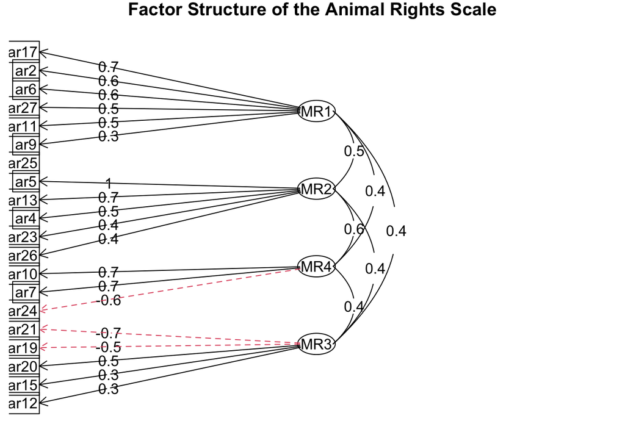

```r
fa.diagram(fa_model,
           cut = 0.3,
           main = "Factor Structure of the Animal Rights Scale")
```

```r
# 1. Create a reference list of item descriptions
# (I added the descriptions for the items in your final model)
item_descriptions <- c(
  "ar17" = "Viable alternatives to animal research exist",
  "ar2"  = "Animal research cannot be justified",
  "ar6"  = "Medical research on animals is unnecessary",
  "ar27" = "Psychological research on animals is unnecessary",
  "ar11" = "Pests should be removed rather than killed",
  "ar9"  = "Need more regulations governing animal research",
  "ar25" = "Most cosmetics research is unnecessary",
  "ar5"  = "Wrong to wear leather jackets and pants",
  "ar13" = "Wrong to wear leather belts and shoes",
  "ar4"  = "No right to use horse for transport/entertainment",
  "ar23" = "Wrong to wear animal fur",
  "ar26" = "Morally wrong to eat chicken and fish",
  "ar10" = "Morally wrong to eat beef and 'red' meat",
  "ar7"  = "Considered becoming a vegetarian",
  "ar24" = "Appropriate to kill animals that destroy property",
  "ar21" = "No alternatives but to do animal research",
  "ar19" = "New drugs should be tested on animals first",
  "ar20" = "Very concerned about pain and suffering",
  "ar15" = "Time to extend basic rights to animals",
  "ar12" = "Animals should have same rights as humans"
)

# 2. Extract Loadings and Communalities
#    fa.sort() automatically groups items by their strongest factor
sorted_model <- fa.sort(fa_model)
loadings_df <- data.frame(unclass(sorted_model$loadings))
communalities <- sorted_model$communalities

# 3. Clean up the table
final_table <- loadings_df %>%
  # Add the communality column (h2)
  mutate(h2 = communalities) %>%
  # Add the descriptions (matching by row name)
  mutate(Description = item_descriptions[rownames(.)]) %>%
  # Round all numbers to 2 decimal places
  mutate(across(where(is.numeric), \(x) round(x, 2))) %>%
  # Move Description to the front
  select(Description, everything())

# 4. Hide small loadings (make them blank) for readability
#    (This affects the view only, converts numbers to text)
final_table_clean <- final_table %>%
  mutate(across(starts_with("MR"), \(x) ifelse(abs(x) < 0.3, "", x))) %>%
  rename(
    "Animal Research" = MR1,
    "Animal as product" = MR2,
    "Killing animals" = MR4,
    "Animal rights" = MR3,
    "Communality (h2)" = h2
  )

# 5. View the final table
datatable(final_table_clean, options = list(pageLength = 30))
```

[output not shown]

[output cut: 10 more lines]

## Run linear regression

Calculate the factor scores.

```r
factor_score_labels <- fa_model$scores
```

Bind factor scores to the original dataset.

```r
dataset_with_scores <- cbind(df_raw, factor_score_labels)
```

Run the linear regression.

```r
fit <- lm(liberal ~ MR1 + MR2 + MR4 + MR3, data = dataset_with_scores)

vif(fit)
```

```
##      MR1      MR2      MR4      MR3
## 1.753136 1.886982 1.975184 1.649411
```

**ANSWER** VIF values are below 2, which is acceptable and we can state we see no multicollinearity.

```r
summary(fit)
```

```
##
## Call:
## lm(formula = liberal ~ MR1 + MR2 + MR4 + MR3, data = dataset_with_scores)
##
## Residuals:
##      Min       1Q   Median       3Q      Max
## -2.28602 -0.58632  0.08727  0.35264  2.31021
##
## Coefficients:
##             Estimate Std. Error t value Pr(>|t|)
## (Intercept)  2.90730    0.06632  43.834  < 2e-16 ***
## MR1         -0.04787    0.09611  -0.498 0.619135
## MR2         -0.16443    0.09087  -1.810 0.072412 .
## MR4          0.39522    0.10334   3.825 0.000194 ***
## MR3          0.03621    0.09803   0.369 0.712362
## ---
## Signif. codes:  0 '***' 0.001 '**' 0.01 '*' 0.05 '.' 0.1 ' ' 1
##
## Residual standard error: 0.815 on 146 degrees of freedom
##   (3 observations deleted due to missingness)
## Multiple R-squared:  0.1079, Adjusted R-squared:  0.08349
## F-statistic: 4.416 on 4 and 146 DF,  p-value: 0.002125
```

**ANSWER** he regression model indicated that Factor 4 (Opposition to killing animals) was the only significant predictor of political views (b=0.39,t=3.83,p<.001).

# Summary

Note: I wrote the codes and my inline comments myself - but I asked an LLM to summarize my comments and process to this section.

### Summary

- **Data quality & factorability**
  - All AR items were within the expected 1–5 range, and I did not detect any obvious coding errors.
  - The correlation matrix was mostly in the low–moderate range; only ar5–ar13 showed a very high correlation (r = .83), which I flagged but initially kept.
  - The overall KMO was excellent (0.88), and all items were in the acceptable range, so the data were clearly suitable for factor analysis.
- **Assumptions & method choices**
  - Mardia’s test and the Q–Q plot both indicated strong violations of multivariate normality.
  - Several items showed substantial skewness and/or kurtosis.
  - Because of this, I decided not to use Maximum Likelihood and chose MINRES with oblimin (oblique) rotation instead, assuming the factors are correlated.
- **Number of factors**
  - Parallel analysis (based on MINRES factor analysis) and the scree plot both supported a 4-factor solution.
  - I therefore kept 4 factors in all subsequent models.
- **Trials to exclude variables**
  - The initial 4-factor model had a low mean communality (around 0.41), so I tried two approaches to improve it:
    1. First, I removed items with the most extreme skewness/kurtosis (ar3, ar10, ar14, ar26) to work with “more normal” data. This did not meaningfully improve the communalities.
    2. Next, I returned to the original model and excluded up to eight items with the lowest communalities and weakest contribution (ar16, ar3, ar28, ar8, ar14, ar18, ar22, ar1), staying within the assignment’s limit.
  - After this second step, the mean communality increased to about 0.49, and most remaining items were above the 0.30 rule-of-thumb (with ar25 at 0.29 as a borderline case).
- **Final factor structure**
  - The final rotated solution was interpretable, with mostly clear dominant loadings and only a couple of notable cross-loadings.
  - I labelled the factors as:
    1. Opposition to animal research
    2. Opposition to using animals for human products
    3. Animals should have rights similar to people
    4. Opposition to killing animals
  - Factors are reasonably coherent conceptually.
- **Regression on liberalism**
  - I saved the factor scores and used them as predictors of self-rated liberalism.
  - VIF values were all below 2, so I did not find problematic multicollinearity.
  - Only the “Opposition to Killing Animals” factor significantly predicted liberalism (b = 0.39, t = 3.83, p < .001); the other three factors were not significant.
  - In this sample, the attitude towards killing animals were the clearest attitudinal marker of how liberal participants rated themselves.